# How Bird’s Body Mass and Traits Shape Habitat Prefrences

by Tidybear123: Ishildur, Laith, Jason, & Richard

2025-11-30

## Introduction

Bird habitats influence how birds move, forage, and fly, which can lead to differences in their physical traits. We wanted to explore whether habitat type affects key characteristics, with a particular focus on body mass. We found a paper that suggest that there is a link between body mass and habitat structure within Passeriformes, in particular when comparing dense and open habitats (Polo, V., & Carrascal, L. M., 1999). This motivated us to test whether the AVONET data set shows similar patterns. Our study focuses on Passeriformes, the largest and most diverse bird order, representing around 60% of all bird species (Austin, 2025). Based on this, we asked:  
How does body mass in Passerformies vary between open and dense habitats, and to what extent do additional traits help explain preferences in habitat density?

## Data Overview

For this report, we will be using the data set AVONET: morphological, ecological and geographical data for all birds. Each observation is a species, containing information about its functional traits including ecological variables, continuous morphological traits, and information on range size and location. We chose to focus on habitat, habitat density, mass and some other body measurements.

During our cleaning process we found that to get the sample sizes of dense and open habitats approximately equal we had to combine semi-open (2) and open (3) habitats to one value called “Open”.

## Initial Exploration

First we were curious to see which type of habitats were most common in each group of dense and open habitats.

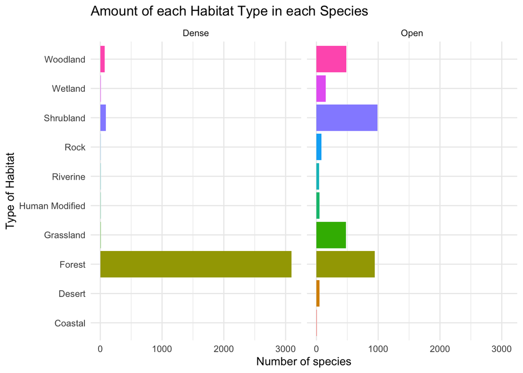

We found that forest were most common within dense habitats, and open habitats being wider spread but with the majority belonging to shrubland, forest and woodland habitats. Because of the strong correlation between forest and dense habitats, we decided not to include habitat as a exploratory variable in our modelling.

## Exploratory Statistics

We started by calculating the mean, median and standard deviation within each group. This showed that both the mean and median were lower in open habitats, suggesting that species living in open habitats tend to be smaller on average, and that their most typical body size is also smaller compared to species in dense habitats. Furthermore, the standard deviation seems to lie between 54 g and 58 g, indicating some spread in the data, with open habitat having the largest spread.

| Habitat.Density | Mean | Median | Standard_Deviation | Total |
| --- | --- | --- | --- | --- |
| Dense | 38.94 | 21.5 | 54.16 | 3277 |
| Open | 33.94 | 20.3 | 57.13 | 3276 |

#### Outliers

When examining the outliers, we found that most of them belong to the crow family (Crovidae). However, because they represent a small proportion of the total data set and their large body size is biologically meaningful rather than an error, they do not meaningfully affect the overall patterns we observe.

| rank | Family1_Dense | Family1_Open | Mass_Dense | Mass_Open |
| --- | --- | --- | --- | --- |
| 1 | Menuridae | Corvidae | 972.6 | 1135.0 |
| 2 | Menuridae | Corvidae | 928.0 | 928.0 |
| 3 | Corvidae | Corvidae | 635.0 | 894.0 |
| 4 | Corvidae | Corvidae | 635.0 | 676.3 |
| 5 | Corvidae | Corvidae | 518.8 | 644.3 |
| 6 | Corvidae | Corvidae | 467.0 | 611.0 |
| 7 | Paradisaeidae | Corvidae | 432.7 | 573.5 |
| 8 | Icteridae | Corvidae | 405.3 | 570.0 |
| 9 | Corvidae | Corvidae | 401.0 | 553.0 |
| 10 | Icteridae | Corvidae | 383.9 | 540.4 |

## Body Mass Distrubution

When looking at the distribution of body mass we used the log scale to spread the small values and compresses the large ones, reducing skewness while keeping relative differences intact.

### Distubution of Body Mass as Box Plots

Looking deeper into the distribution of body mass we made a box plot and histogram. The box plot shows us that the interquartile range of species in open habitats are slightly smaller compered to dense habitats. Indicating that open birds has a smaller spread in the middle 50%.

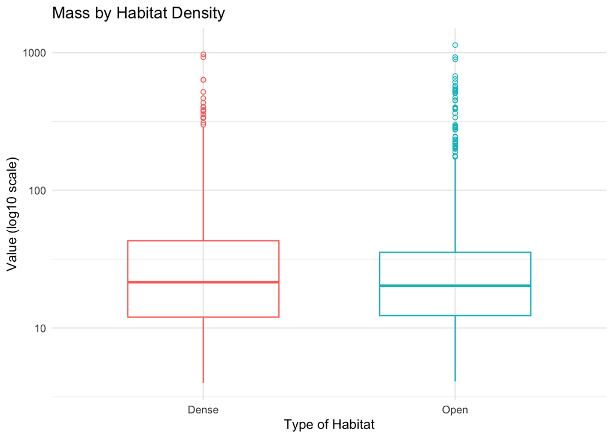

### Distubution of Body Mass as Histogram

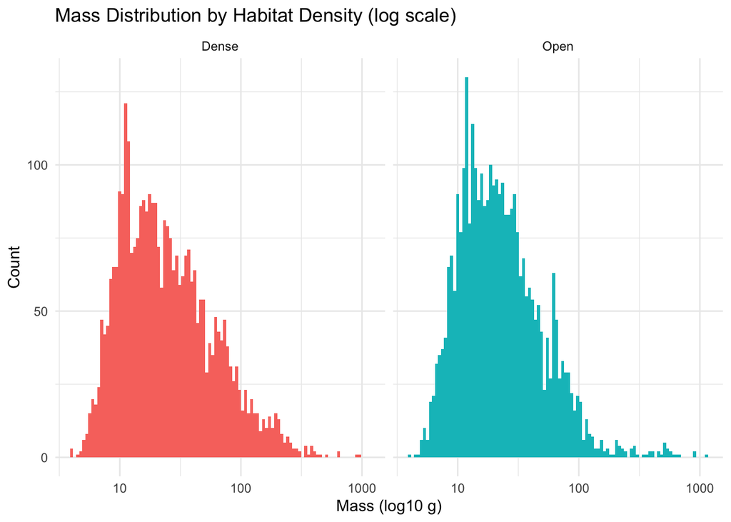

## Predictive Modelling

### Choice of Model

We wanted to see if mass as the explanatory variable alone is enough to predict whether a species is from a dense habitat or not, or if adding several other body measurements would create a better model. So then we created two models using logistic regression, as our outcome is binary (Dense habitat/Open habitat).

### Comparing Two Models

Splitting the data, we used 75% of the data set as our training data and then 25% as our test data. Furthermore, we used cross validation and split the data into ten folds to check the generalizebility of the model and avoid overfitting.

```r
# Splitting the data
set.seed(222)

BirdLife_split <- initial_split(BirdLife)
train_data <- training(BirdLife_split)
test_data <- testing(BirdLife_split)

# Using cross validation
folds <- vfold_cv(train_data, v = 10)
```

We created a workflow, using only mass as the explanatory variable.

```r
rec_mass <- recipe(
  Habitat.Density ~ Mass,
  data = train_data
) %>%
  step_zv(all_predictors())

# Add the GLM model specification
wflow_mass <- workflow() %>%
  add_model(mod_glm) %>%
  add_recipe(rec_mass)

# Fit the model on the training data
cv_mass <- fit_resamples(
  wflow_mass,
  resamples = folds,
  metrics = metric_set(roc_auc),
  control = control_resamples(save_pred = TRUE) # Save predictions for later analysis
)
```

Then we created a second model using several other body measurements as explanatory variables, including: Mass, wing length, beak length, width, depth, wing length and tail length. We removed predictors with zero variance, then we fitted the model.

```r
rec_multi <- recipe(
  Habitat.Density ~ Mass + Wing.Length + Beak.Length_Culmen + Beak.Length_Nares
+ Beak.Width + Beak.Depth + Tarsus.Length + Wing.Length + Kipps.Distance + Tail.Length + Secondary1,
  data = train_data
) %>%
  step_zv(all_predictors())

# Add the GLM model specification
wflow_multi <- workflow() %>%
  add_model(mod_glm) %>%
  add_recipe(rec_multi)

# Fit the model on the training data
fit_multi <- wflow_multi %>%
  fit(data = train_data)

cv_multi <- fit_resamples(
  wflow_multi,
  resamples = folds,
  metrics = metric_set(roc_auc),
  control = control_resamples(save_pred = TRUE)) # Save predictions for later analysis
```

Then we compered the two models, based on area under the ROC curve.

| Metric | Mean | Std_Error | Model |
| --- | --- | --- | --- |
| roc_auc | 0.527 | 0.010 | Mass only |
| roc_auc | 0.697 | 0.008 | All measurements |

Observe that using mass as the only explanatory variable gives 0.53 as the area under the ROC curve, meaning that its predictions are close to random. On the other hand, the second model, shows a area under the ROC curve being almost 0.70 indicating a better prediction accuracy.

| Term | Estimate | Std_Error | Statistic | p.value |
| --- | --- | --- | --- | --- |
| (Intercept) | 0.247 | 0.161 | 1.531 | 0.126 |
| Mass | -0.008 | 0.001 | -5.646 | 0.000 |
| Wing.Length | 0.043 | 0.025 | 1.679 | 0.093 |
| Beak.Length_Culmen | -0.200 | 0.021 | -9.455 | 0.000 |
| Beak.Length_Nares | 0.180 | 0.025 | 7.202 | 0.000 |
| Beak.Width | -0.272 | 0.037 | -7.278 | 0.000 |
| Beak.Depth | 0.256 | 0.030 | 8.507 | 0.000 |
| Tarsus.Length | 0.062 | 0.008 | 7.247 | 0.000 |
| Kipps.Distance | 0.025 | 0.026 | 0.976 | 0.329 |
| Tail.Length | 0.015 | 0.002 | 8.250 | 0.000 |
| Secondary1 | -0.070 | 0.025 | -2.763 | 0.006 |

Looking further into the second model, we see that some explanatory variables, in particular Beak.Depth and Beak.Width seem to have a correlation with the type of habitat of a species. The positive coefficient in Beak.Depth tells us that there is a positive correlation, indicating that a larger value in Beak.Depth gives us a larger probability of the species being from a dense habitat. While the negative coefficient in Beak.Width tells us that there is a negative correlation, with a larger value decreasing the probability of the species being from a dense habitat. Looking at the low p.values tells us that the observed difference is unlikely to be due to chance, with the exception of Kipps.Distance and Wing.Length. Furthermore, overall the statistical errors seem low, suggesting that model is confident in that the coefficients are estimated with little variability.

## Model Evaluation

Moving forward we chose to use the second model on our test data, and plotted the ROC curve to evaluate how well using physical body measurements could predict whether a species is from a dense habitat.

```
## # A tibble: 11 × 5
##    term               estimate std.error statistic  p.value
##    <chr>                 <dbl>     <dbl>     <dbl>    <dbl>
##  1 (Intercept)          0.0421   0.295       0.143 8.86e- 1
##  2 Mass                -0.0109   0.00300    -3.64  2.70e- 4
##  3 Wing.Length          0.0436   0.0435      1.00  3.17e- 1
##  4 Beak.Length_Culmen  -0.146    0.0328     -4.45  8.73e- 6
##  5 Beak.Length_Nares    0.112    0.0379      2.95  3.16e- 3
##  6 Beak.Width          -0.325    0.0654     -4.97  6.71e- 7
##  7 Beak.Depth           0.342    0.0541      6.33  2.42e-10
##  8 Tarsus.Length        0.0328   0.0143      2.30  2.14e- 2
##  9 Kipps.Distance       0.0240   0.0444      0.542 5.88e- 1
## 10 Tail.Length          0.0155   0.00303     5.12  3.05e- 7
## 11 Secondary1          -0.0646   0.0435     -1.49  1.37e- 1
```

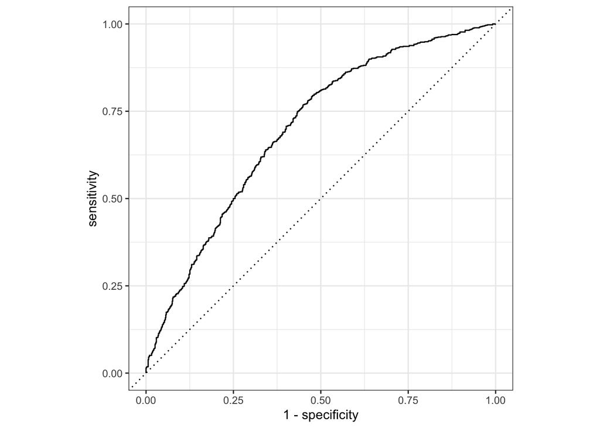

```
## # A tibble: 1 × 3
##   .metric .estimator .estimate
##   <chr>   <chr>          <dbl>
## 1 roc_auc binary         0.699
```

The model achieved a AUC of almost 0.7, indicating that there is some correlation between physical traits in birds and their habitat preferences and that our model is moderately effective at predicting habitat density based on body measurements.

|  | Habitat is Dense | Habitat is Open |
| --- | --- | --- |
| Labelled Dense | 571 | 323 |
| Labelled Open | 255 | 490 |

Sensitivity = 571/(255+571) = 0.69  
Specificity = 490/(323+490) = 0.60

First, the sensitivity of the model tells us it does a moderately good job at identifying dense habitat species correctly (true positive), but still misses a noticeable amount (false negatives). Secondly, looking at the specificity we find that does a fair job at identifying open habitat species (true negatives).

## Limitations

One limitation of our project is that the trait values in the data set are based on species averages, even though the number of samples per species varies widely (from 1 to 784 individuals). This may cause some of the values to be skewed due to outliers and extreme values. Another limitation is that when we were doing the modeling we discovered that the number of data for when habitat density is 1 is almost twice as much as that of 2 and 3. So in order to make a more even sample size, we combined habitat density 2 and 3 together and considered it as “Open” while 1 is considered “Dense”, this may cause some problems as only half the data for open density habitats are actually for open density while the other half are technically considered semi-open.

## Summary

In conclusion, our results differed from the journal we compared against, which reported that birds in dense habitats tend to be lighter than those in open habitats. This difference may be due to the scope of the data: the journal focused on 55 species in central Spain, while we analysed all Passeriformes species available in the AVONET dataset, along with the limitations of our study. In our analysis, we found no clear relationship between body mass and habitat density. However, some other traits, especially beak depth and beak width, showed stronger associations with habitat type. Future work could explore these traits further to better understand how they relate to habitat use.

## References

Tobias, J. A., Sheard, C., Pigot, A. L., M. Devenish, A. J., Yang, J., Sayol, F., C. Neate-Clegg, M. H., Alioravainen, N., Weeks, T. L., Barber, R. A., Walkden, P. A., A. MacGregor, H. E., I. Jones, S. E., Vincent, C., Phillips, A. G., Marples, N. M., Montaño-Centellas, F. A., Leandro-Silva, V., Claramunt, S., . . . Schleuning, M. (2022). ‘AVONET: morphological, ecological and geographical data for all birds’. Retrieved from: https://figshare.com/s/b990722d72a26b5bfead. (Accessed 30/11/2025)

Polo, V., & Carrascal, L. M. (1999). Shaping the body mass distribution of Passeriformes: Habitat use and body mass are evolutionarily and ecologically related. Journal of Animal Ecology. Retrieved from: https://besjournals.onlinelibrary.wiley.com/doi/10.1046/j.1365-2656.1999.00282.x. (Accessed 30/11/2025)

Austin, O.L., Gill, F., Clench, M.H. (2025, November 20). passeriform. Encyclopedia Britannica. Retrieved from: https://www.britannica.com/animal/passeriform. (Accessed 30/11/2025)

We used ChatGPT (v5) to help with debugging of the code, as well as improving clarity of our writing.